# A quick guide into `stvcGLMstack`

Bayesian inference for spatial-temporal non-Gaussian data using predictive stacking

Soumyakanti Pan, e-mail: span18@ucla.edu

# 1 Introduction

This document is a guide to the code as it appears on the GitHub repository stvcGLMstack that has been developed as a supplement to the methodology appearing in Pan et al. (2024).

Soumyakanti Pan, Lu Zhang, Jonathan R. Bradley, and Sudipto Banerjee. 2024. *Bayesian Inference for Spatial-temporal Non-Gaussian Data Using Predictive Stacking.* https://arxiv.org/abs/2406.04655.

The code implement Bayesian predictive stacking for analyzing outcomes that arrive either as Poisson/binomial counts or binary over spatial-temporal coordinates.

## 1.1 Package requirements

The functions presented here are part of the development version of the R package `spStack` (https://github.com/SPan-18/spStack-dev).

Successful installation of spStack and other functions in this repository depends on installation of the following packages - `CVXR`, `future`, `future.apply`, `ggplot2`, `MBA`, `rstudioapi`, `ggpubr`, `knitr`, `rmarkdown`, `spBayes`, `dplyr`.

```r
# Required package names
packages <- c("CVXR", "future", "future.apply", "ggplot2", "MBA", "rstudioapi",
              "ggpubr", "knitr", "spBayes", "dplyr", "pak")

# Install packages not yet installed
installed_packages <- packages %in% rownames(installed.packages())
if (any(installed_packages == FALSE)) {
  install.packages(packages[!installed_packages],
                   repos = "http://cran.us.r-project.org")
}
```

> **Important:** If running for the first time, install `spStack` from GitHub by running the following code chunk. For subsequent runs, this code evaluation can be turned to FALSE.

```r
pak::pak("SPan-18/spStack-dev")
```

```
ℹ Loading metadata database✔ Loading metadata database ... done

✔ All system requirements are already installed.

ℹ No downloads are needed
✔ 1 pkg + 46 deps: kept 23 [5.7s]
```

## 1.2 Synthetic Poisson count data

The following script simulates a Poisson count data with sample size $n = 500$, and space-time coordinates sampled uniformly inside $[0, 1]^2 \times [0, 1]$.
$$\begin{equation}
\begin{split}
y(\ell_i) &\sim \mathrm{Poisson}(\exp(x(\ell_i)^{ \top }\beta + \tilde{x}(\ell_i)^{ \top }z(\ell_i))), \quad i = 1, \ldots, n\\
z_j(\ell) &\overset{\text{ind}}{\sim} \mathrm{GP}(0, \sigma^2_{z_j} R_j(\cdot, \cdot; {\theta_{\text{sp}}}_j)), \quad j = 1, \ldots, r
\end{split}
\end{equation}$$
Here, $x(\ell)$ is $2\times 1$ consisting of an intercept and one predictor sampled from the standard normal distribution, and, the fixed effects $\beta = (5, -0.5)$. We set $\tilde{x}(\ell) = x(\ell)$, deeming all covariates to have spatially-temporally varying coefficients. Under the independent process assumption, $z_j(\ell) \sim \mathrm{GP}(0, \sigma^2_{z_j} R_j(\cdot, \cdot; {\theta_{\text{sp}}}_j))$ for $j = 1, 2$ with $\sigma^2_{z_1} = 0.25$, $\sigma^2_{z_2} = 0.5$ and, $(\phi_{11}, \phi_{21}) = (2, 3)$ and, $(\phi_{12}, \phi_{22}) = (2, 4)$.

```r
source('sim_stvcPoisson.R')
head(dat)
```

| s1 | s2 | t_coords | x1 | y | z1_true | z2_true |
| --- | --- | --- | --- | --- | --- | --- |
| 0.7392403 | 0.9364087 | 0.9872869 | 0.2153162 | 65 | -0.5385494 | -0.8737048 |
| 0.0532836 | 0.7527885 | 0.9645316 | 0.1837478 | 36 | -1.0252729 | -0.4175633 |
| 0.8764126 | 0.6788715 | 0.7846000 | 1.0860493 | 14 | -1.0458098 | -0.1515509 |
| 0.8870322 | 0.9751280 | 0.6615492 | 0.0287130 | 128 | -0.0420406 | -0.2762596 |
| 0.6974767 | 0.6675319 | 0.9751077 | 1.0422541 | 22 | -0.6936237 | -1.0980381 |
| 0.5676317 | 0.2406235 | 0.9200938 | 0.0882655 | 74 | -0.6949118 | 0.2453041 |

The simulated data is stored in the variable `dat`.

### 1.2.1 Fitting Poisson regression using stacking

See example below. We fit the multivariate spatial-temporal process model for the varying coefficients.

```r
library(spStack)

## Step 1: create a set of candidate models
params_list <- list(phi_s = c(2, 4, 5),
                    phi_t = c(3, 4, 6),
                    boundary = c(0.5))

mod.list <- candidateModels(params_list, "cartesian")
class(mod.list)
```

```
[1] "candidateModels"
```

```r
## Step 2: call main function for fitting all candidate models
mod1 <- stvcGLMstack(y ~ x1 + (x1), data = dat, family = "poisson",
                     sp_coords = as.matrix(dat[, c("s1", "s2")]),
                     time_coords = as.matrix(dat[, "t_coords"]),
                     cor.fn = "gneiting-decay",
                     process.type = "multivariate",
                     candidate.models = mod.list,
                     loopd.controls = list(method = "CV", CV.K = 10, nMC = 500),
                     n.samples = 1000, verbose = TRUE)
```

```
STACKING WEIGHTS:

          | phi_s | phi_t | boundary | weight |
+---------+-------+-------+----------+--------+
| Model 1 |      2|      3|       0.5| 0.000  |
| Model 2 |      4|      3|       0.5| 0.000  |
| Model 3 |      5|      3|       0.5| 0.502  |
| Model 4 |      2|      4|       0.5| 0.000  |
| Model 5 |      4|      4|       0.5| 0.000  |
| Model 6 |      5|      4|       0.5| 0.000  |
| Model 7 |      2|      6|       0.5| 0.000  |
| Model 8 |      4|      6|       0.5| 0.197  |
| Model 9 |      5|      6|       0.5| 0.301  |
+---------+-------+-------+----------+--------+
```

```r
class(mod1)
```

```
[1] "stvcGLMstack"
```

```r
## Step 3: Recover marginalized scale parameters
mod1 <- recoverGLMscale(mod1)

## Step 4: Sample model parameters from the stacked posterior
post_samps <- stackedSampler(mod1)
```

Now, `post_samps` contains samples of model parameters from the *stacked posterior*. The following figure shows the posterior samples of the spatial-temporal process associated with the varying coefficient of the predictor `x1` at the observed locations against the corresponding true values of the process with which the data was generated.

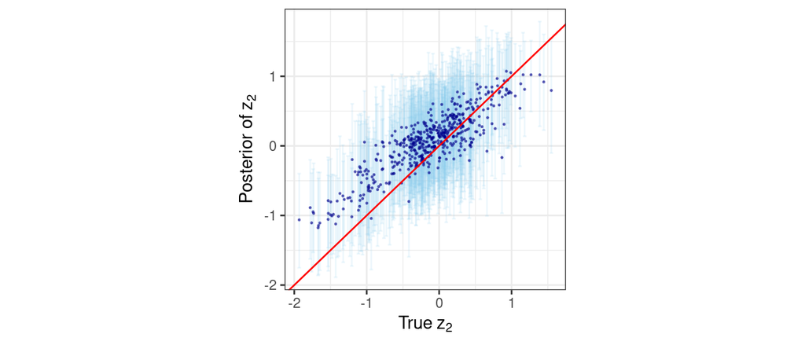

# References

Pan, Soumyakanti, Lu Zhang, Jonathan R. Bradley, and Sudipto Banerjee. 2024. “Bayesian Inference for Spatial-Temporal Non-Gaussian Data Using Predictive Stacking.” https://arxiv.org/abs/2406.04655.